# Project 1: Wrangling, Exploration, Visualization

SDS322E

```r
library(tidyverse)
statedata <- read_csv("state_info.csv")
arrestdata <- read_csv("USArrests.csv")
```

## Data Wrangling, Exploration, Visualization

### Tanish Bhowmick, tb33385

#### Introduction

```r
head(statedata)
```

```
## # A tibble: 6 × 10
##   States     state.abb Population Income Illiteracy `Life Exp` Murder `HS Grad`
##   <chr>      <chr>          <dbl>  <dbl>      <dbl>      <dbl>  <dbl>     <dbl>
## 1 Alabama    AL              3615   3624        2.1       69.0   15.1      41.3
## 2 Alaska     AK               365   6315        1.5       69.3   11.3      66.7
## 3 Arizona    AZ              2212   4530        1.8       70.6    7.8      58.1
## 4 Arkansas   AR              2110   3378        1.9       70.7   10.1      39.9
## 5 California CA             21198   5114        1.1       71.7   10.3      62.6
## 6 Colorado   CO              2541   4884        0.7       72.1    6.8      63.9
## # … with 2 more variables: Frost <dbl>, Area <dbl>
```

```r
head(arrestdata)
```

```
## # A tibble: 6 × 6
##   States     state.abb Murder Assault UrbanPop  Rape
##   <chr>      <chr>      <dbl>   <dbl>    <dbl> <dbl>
## 1 Alabama    AL          13.2     236       58  21.2
## 2 Alaska     AK          10       263       48  44.5
## 3 Arizona    AZ           8.1     294       80  31
## 4 Arkansas   AR           8.8     190       50  19.5
## 5 California CA           9       276       91  40.6
## 6 Colorado   CO           7.9     204       78  38.7
```

The datasets above are taken from some of the inbuilt datasets from R. The first dataset displays statistics about the individual states, including population, income, illiteracy, and murder rates. The second dataset shows violent crime rates for different states. This types of violent crimes include murder, assault, rape, and the dataset also shows the percentage of the state population living in urban areas. I feel that these two datasets could show interesting correlation between the characteristics of a state and the crime rates in said states.

#### Tidying: Reshaping

If your datasets are tidy already, demonstrate that you can reshape data with pivot wider/longer here (e.g., untidy and then retidy). Alternatively, it may be easier to wait until the wrangling section so you can reshape your summary statistics. Note here if you are going to do this.

```r
pivot_longer(statedata, cols = 3:10) -> gatherstate
gatherstate
```

```
## # A tibble: 400 × 4
##    States  state.abb name         value
##    <chr>   <chr>     <chr>        <dbl>
##  1 Alabama AL        Population  3615
##  2 Alabama AL        Income      3624
##  3 Alabama AL        Illiteracy     2.1
##  4 Alabama AL        Life Exp      69.0
##  5 Alabama AL        Murder        15.1
##  6 Alabama AL        HS Grad       41.3
##  7 Alabama AL        Frost         20
##  8 Alabama AL        Area       50708
##  9 Alaska  AK        Population   365
## 10 Alaska  AK        Income      6315
## # … with 390 more rows
```

```r
pivot_wider(gatherstate, names_from = name, values_from = value)
```

```
## # A tibble: 50 × 10
##    States      state.abb Population Income Illiteracy `Life Exp` Murder `HS Grad`
##    <chr>       <chr>          <dbl>  <dbl>      <dbl>      <dbl>  <dbl>     <dbl>
##  1 Alabama     AL              3615   3624        2.1       69.0   15.1      41.3
##  2 Alaska      AK               365   6315        1.5       69.3   11.3      66.7
##  3 Arizona     AZ              2212   4530        1.8       70.6    7.8      58.1
##  4 Arkansas    AR              2110   3378        1.9       70.7   10.1      39.9
##  5 California  CA             21198   5114        1.1       71.7   10.3      62.6
##  6 Colorado    CO              2541   4884        0.7       72.1    6.8      63.9
##  7 Connecticut CT              3100   5348        1.1       72.5    3.1      56
##  8 Delaware    DE               579   4809        0.9       70.1    6.2      54.6
##  9 Florida     FL              8277   4815        1.3       70.7   10.7      52.6
## 10 Georgia     GA              4931   4091        2         68.5   13.9      40.6
## # … with 40 more rows, and 2 more variables: Frost <dbl>, Area <dbl>
```

The above code shows the untidying and retidying of the states dataset. It first applies pivot_longer() to the dataset to make all the numerical values go into one column and have another column that stores all the variable characteristics. However, this becomes a dataset with 400 rows which is difficult to read through. I then apply the pivot_wider() command to retidy the dataset, so that the there are 10 columns and only 50 rows. Each column now holds its own characteristic and only numerical values making the data much easier to read.

#### Joining/Merging

```r
statedata %>%
    left_join(arrestdata, by = c("States", "state.abb")) ->
    joindata
head(joindata)
```

```
## # A tibble: 6 × 14
##   States     state.abb Population Income Illiteracy `Life Exp` Murder.x `HS Grad`
##   <chr>      <chr>          <dbl>  <dbl>      <dbl>      <dbl>    <dbl>     <dbl>
## 1 Alabama    AL              3615   3624        2.1       69.0     15.1      41.3
## 2 Alaska     AK               365   6315        1.5       69.3     11.3      66.7
## 3 Arizona    AZ              2212   4530        1.8       70.6      7.8      58.1
## 4 Arkansas   AR              2110   3378        1.9       70.7     10.1      39.9
## 5 California CA             21198   5114        1.1       71.7     10.3      62.6
## 6 Colorado   CO              2541   4884        0.7       72.1      6.8      63.9
## # … with 6 more variables: Frost <dbl>, Area <dbl>, Murder.y <dbl>,
## #   Assault <dbl>, UrbanPop <dbl>, Rape <dbl>
```

#### Wrangling

```r
joindata %>%
    filter(Illiteracy <= 1) %>%
    arrange(Illiteracy) %>%
    select(States, Illiteracy, UrbanPop, Murder.y, Assault, Rape)
```

```
## # A tibble: 26 × 6
##    States       Illiteracy UrbanPop Murder.y Assault  Rape
##    <chr>             <dbl>    <dbl>    <dbl>   <dbl> <dbl>
##  1 Iowa                0.5       57      2.2      56  11.3
##  2 Nevada              0.5       81     12.2     252  46
##  3 South Dakota        0.5       45      3.8      86  12.8
##  4 Idaho               0.6       54      2.6     120  14.2
##  5 Kansas              0.6       66      6       115  18
##  6 Minnesota           0.6       66      2.7      72  14.9
##  7 Montana             0.6       53      6       109  16.4
##  8 Nebraska            0.6       62      4.3     102  16.5
##  9 Oregon              0.6       67      4.9     159  29.3
## 10 Utah                0.6       80      3.2     120  22.9
## # … with 16 more rows
```

```r
joindata %>%
    mutate(index = substring(States, 1, 1)) -> joindata
joindata %>%
    group_by(index) %>%
    summarize(mean(Murder.y))
```

```
## # A tibble: 19 × 2
##    index `mean(Murder.y)`
##    <chr>            <dbl>
##  1 A                10.0
##  2 C                 6.73
##  3 D                 5.9
##  4 F                15.4
##  5 G                17.4
##  6 H                 5.3
##  7 I                 5.6
##  8 K                 7.85
##  9 L                15.4
## 10 M                 7.96
## 11 N                 7.79
## 12 O                 6.27
## 13 P                 6.3
## 14 R                 3.4
## 15 S                 9.1
## 16 T                13.0
## 17 U                 3.2
## 18 V                 5.35
## 19 W                 4.78
```

The above wrangling code uses the mutate, group_by, and summarize commands. It first uses mutate to create a new variable called “index” that stores the first letter of every state providing the ability to index the states just by the first letter. The code then uses the group_by function to organize the dataset by the first letters of every state. Finally, it uses the summarize function to calculate the average murder rate by the first letter of every state.

```r
joindata %>%
    summarize(mean = mean(Population), sd = sd(Population), var = var(Population),
        min = min(Population), max = max(Population))
```

```
## # A tibble: 1 × 5
##    mean    sd       var   min   max
##   <dbl> <dbl>     <dbl> <dbl> <dbl>
## 1 4246. 4464. 19931684.   365 21198
```

```r
joindata %>%
    summarize(mean = mean(Income), sd = sd(Income), var = var(Income),
        min = min(Income), max = max(Income))
```

```
## # A tibble: 1 × 5
##    mean    sd     var   min   max
##   <dbl> <dbl>   <dbl> <dbl> <dbl>
## 1 4436.  614. 377573.  3098  6315
```

```r
joindata %>%
    summarize(mean = mean("Life Exp"), sd = sd("Life Exp"), var = var("Life Exp"),
        min = min("Life Exp"), max = max("Life Exp"))
```

```
## # A tibble: 1 × 5
##    mean    sd   var min      max
##   <dbl> <dbl> <dbl> <chr>    <chr>
## 1    NA    NA    NA Life Exp Life Exp
```

```r
joindata %>%
    summarize(mean = mean(Area), sd = sd(Area), var = var(Area),
        min = min(Area), max = max(Area))
```

```
## # A tibble: 1 × 5
##     mean     sd         var   min    max
##    <dbl>  <dbl>       <dbl> <dbl>  <dbl>
## 1 70736. 85327. 7280748061.  1049 566432
```

```r
joindata %>%
    summarize(mean = mean(Murder.y), sd = sd(Murder.y), var = var(Murder.y),
        min = min(Murder.y), max = max(Murder.y))
```

```
## # A tibble: 1 × 5
##    mean    sd   var   min   max
##   <dbl> <dbl> <dbl> <dbl> <dbl>
## 1  7.79  4.36  19.0   0.8  17.4
```

```r
joindata %>%
    summarize(mean = mean(Assault), sd = sd(Assault), var = var(Assault),
        min = min(Assault), max = max(Assault))
```

```
## # A tibble: 1 × 5
##    mean    sd   var   min   max
##   <dbl> <dbl> <dbl> <dbl> <dbl>
## 1  171.  83.3 6945.    45   337
```

```r
joindata %>%
    summarize(mean = mean(Rape), sd = sd(Rape), var = var(Rape),
        min = min(Rape), max = max(Rape))
```

```
## # A tibble: 1 × 5
##    mean    sd   var   min   max
##   <dbl> <dbl> <dbl> <dbl> <dbl>
## 1  21.2  9.37  87.7   7.3    46
```

```r
joindata %>%
    count(index)
```

```
## # A tibble: 19 × 2
##    index     n
##    <chr> <int>
##  1 A         4
##  2 C         3
##  3 D         1
##  4 F         1
##  5 G         1
##  6 H         1
##  7 I         4
##  8 K         2
##  9 L         1
## 10 M         8
## 11 N         8
## 12 O         3
## 13 P         1
## 14 R         1
## 15 S         2
## 16 T         2
## 17 U         1
## 18 V         2
## 19 W         4
```

#### Visualizing

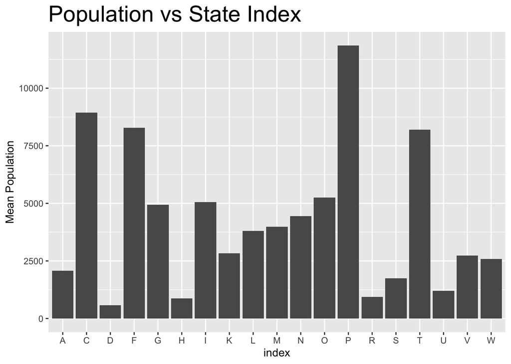

```r
library(ggplot2)

p1 <- ggplot(joindata, aes(index, Population)) + geom_histogram(stat = "summary",
    fun = mean) + labs(title = "Population vs State Index") +
    scale_y_continuous(name = "Mean Population")

p1 + theme(plot.title = element_text(size = rel(2)))
```

Plot 1 shows the mean populations of all the states compared to the alphabetical index. This provides data about whether there is a correlation between the alphabetical index and the mean population. More importantly, it helps provide a simpler organization and visual of where in the alphabet, states with higher populations may lie. For this plot, I created a histogram to plot the Mean population against the alphabetical index. I used the stat=“summary” command here to ensure that the histogram plotted the means of all the population values rather than the individual values.

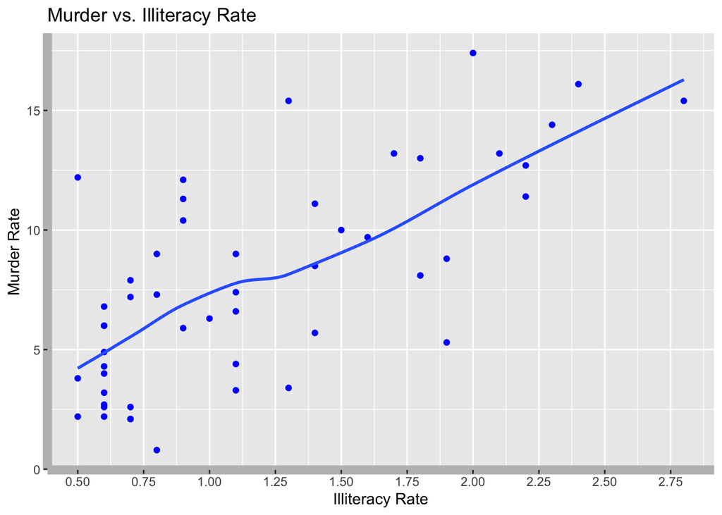

```r
p2 <- ggplot(joindata, aes(Illiteracy, Murder.y)) + geom_point(colour = "blue") +
    geom_smooth(method = "loess", se = F, formula = y ~ x) +
    labs(title = "Murder vs. Illiteracy Rate") + scale_y_continuous(name = "Murder Rate") +
    scale_x_continuous(breaks = round(seq(min(joindata$Illiteracy),
        max(joindata$Illiteracy), by = 0.25), 2), name = "Illiteracy Rate")

p2 + theme(axis.line = element_line(size = 3, colour = "grey"))
```

This plot shows the correlation between murder and illiteracy rates. This plot is meant to provide a visual representation of the correlation between the two variables. We can observe above a positive correlation between murder rates and illiteracy, indicating that in states with higher rates of illiteracy there are higher rates of murder. This can be useful to show politicians the importance of emphasizing education in states to reduce crime rates. The plot was made by creating a scatter plot from Illiteracy and Murder rates in our joined dataset. I then added a smoothed line to better indicate the direction of the correlation. I also increased the number of ticks on the x-axis to better indicate the differences in illiteracy rates for different states.

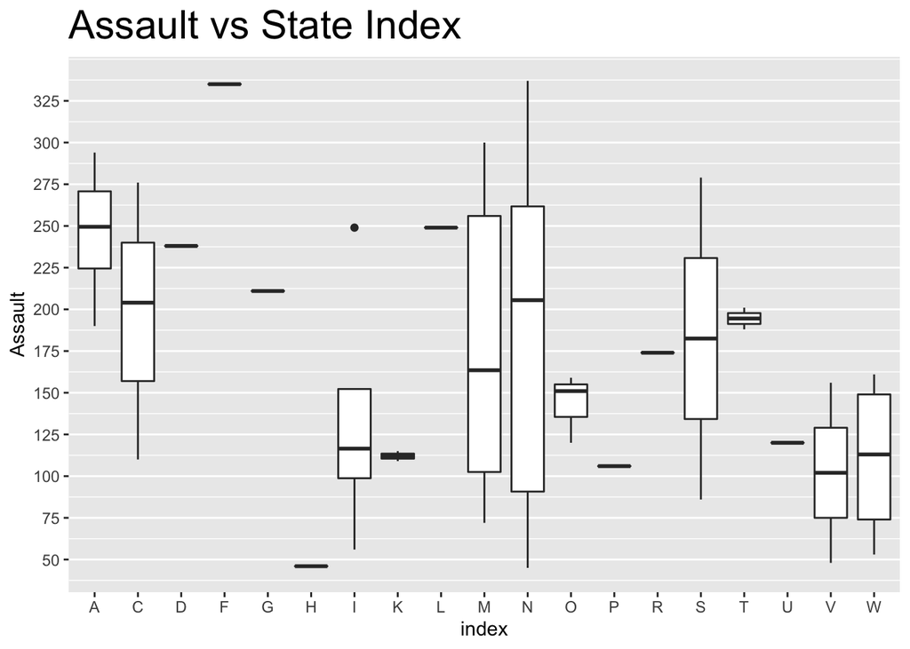

```r
p3 <- ggplot(joindata, aes(index, Assault)) + geom_boxplot() +
    labs(title = "Assault vs State Index") + scale_y_continuous(name = "Assault",
    seq(0, max(joindata$Assault), by = 25))

p3 + theme(plot.title = element_text(size = rel(2)), panel.grid.major.x = element_blank(),
    panel.grid.minor.x = element_blank())
```

This plot shows the relationship between the states alphabetical index and the respective assault rates. This provides a simple visual representation and general idea of which states have higher rates of assault. It also shows the variation present in the different states’ rates of assault seen through the various quartile calculations in the boxplot. It was created by using the geom_boxplot command. The gridlines for the x axis variables were removed to emphasize the axis lines of the assault rates (rather than categorical variable gridlines).